# Fungal compositional analysis on frog skins across localities and vertical positions

Roger Calvas

2026-11-16

# Goals

En este archivo realizaremos el análisis composicional de nuestro dataset de hongos (ITS) normalizado/escalado en la piel de ranas:

1. Cargar el objeto `phyloseq` escalado (`data/its/05_Ordination/scaled_physeq.RData`).
2. Calcular las abundancias relativas de los grupos taxonómicos en tres niveles: A. **Phylum** B. **Genus** C. **ASV**
3. Graficar los grupos principales y explorar cómo varían según la **localidad** (`localidad`, variable categórica) y la **altura desde el suelo** (`posicion_vertical_cm`, variable continua).
1. Cargaremos `data/its/05_Ordination/scaled_physeq.RData`, creado en `analysis/05_Ordination/05_Ordination.Rmd`.

## Outputs

1. Visualizaciones de la composición taxonómica fúngica y cómo varía a través de las localidades y la posición vertical.
2. Pruebas estadísticas exploratorias (Kruskal-Wallis / correlaciones) sobre grupos de interés.

# Compositional Data

Microbial abundance data—like 16S rRNA gene, ITS, or metagenomics data—are typically **compositional:** they represent relative abundances constrained to a constant total (*e.g.,* percent or proportions). This introduces spurious correlations and other issues if analyzed with traditional statistics. This is a very important limitation to microbial data!

INTERPRETATION #1: What are the limitations of interpreting microbial abundance from relative (aka. compositional) rather than absolute counts?

The limitations of relative abundance lie in the interpretation of change: because relative abundances are constrained to a sum of 100% (or 1.0) in each sample, if one fungal taxon increases in absolute abundance, it mathematically forces other taxa to decrease their relative percentage even if their actual cell/spore load on the frog skin did not change.

# Setup

## Timing of this script

```r
# What time did we start running this script?
start_time <- Sys.time()
```

## Load Packages

```r
# Load in the packages
pacman::p_load(tidyverse, devtools, DT, phyloseq, patchwork, ggpubr,
               install = FALSE)

# load colors
source("code/colors.R")
```

## 1. Load in Scaled Phyloseq object

```r
load("data/its/05_Ordination/scaled_physeq.RData")

# Look at the data
scaled_physeq
```

```
## phyloseq-class experiment-level object
## otu_table()   OTU Table:         [ 3030 taxa and 34 samples ]
## sample_data() Sample Data:       [ 34 samples by 89 sample variables ]
## tax_table()   Taxonomy Table:    [ 3030 taxa by 9 taxonomic ranks ]
```

```r
# Intuition check on scaled read depth
min(sample_sums(scaled_physeq))
```

```
## [1] 13998
```

```r
range(sample_sums(scaled_physeq))
```

```
## [1] 13998 14014
```

# Taxonomic Analysis

## A. Phylum

```r
# Create a phylum level dataframe
phylum_df <-
  scaled_physeq %>%
  # Agglomerate all ASV counts within a phylum
  tax_glom(taxrank = "Phylum") %>%
  # Calculate the relative abundance!
  transform_sample_counts(function(x) {x/sum(x)}) %>%
  # Create a dataframe from phyloseq object
  psmelt()

## What are the phylum abundances?
phylum_df %>%
  group_by(Phylum) %>%
  summarize(mean_PercAbund = round(mean(Abundance), digits = 4)) %>%
  arrange(-mean_PercAbund) %>%
  datatable()
```

|  | Phylum | mean_PercAbund |
| --- | --- | --- |
| 1 | p__Ascomycota | 0.5782 |
| 2 | p__Basidiomycota | 0.3079 |
| 3 | p__Mucoromycota | 0.0647 |
| 4 | p__Mortierellomycota | 0.0338 |
| 5 | p__Rozellomycota | 0.0111 |
| 6 | p__Chytridiomycota | 0.0025 |
| 7 | p__Basidiobolomycota | 0.001 |
| 8 | p__Sanchytriomycota | 0.0003 |
| 9 | p__Neocallimastigomycota | 0.0002 |
| 10 | p__Fungi_phy_Incertae_sedis | 0.0001 |

[output cut: 5 more lines]

```r
# Make a list of the top 10 phyla
top10_phyla <-
  phylum_df %>%
  group_by(Phylum) %>%
  summarize(mean_PercAbund = mean(Abundance)) %>%
  arrange(-mean_PercAbund) %>%
  head(n = 10) %>%
  pull(Phylum)

top10_phyla
```

```
##  [1] "p__Ascomycota"            "p__Basidiomycota"
##  [3] "p__Mucoromycota"          "p__Mortierellomycota"
##  [5] "p__Rozellomycota"         "p__Chytridiomycota"
##  [7] "p__Basidiobolomycota"     "p__Sanchytriomycota"
##  [9] "p__Neocallimastigomycota" "p__Kickxellomycota"
```

INTERPRETATION #2: Which phyla in your dataset have the highest relative abundances? What are their abundances? We will focus on these phyla for plotting below. :)

## Stacked Bar Plots (Por Muestra y por Localidad)

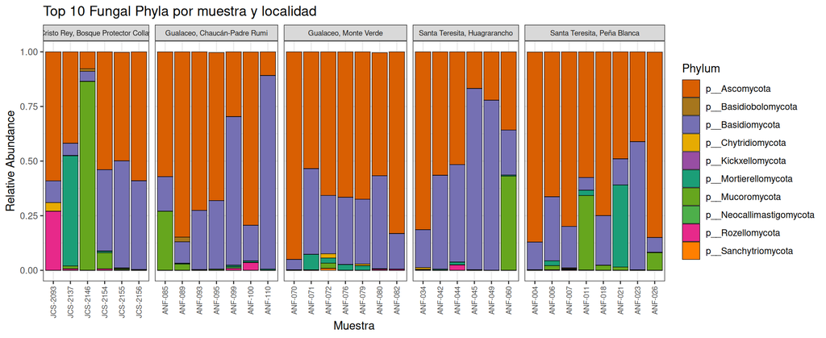

```r
# 1. Stacked Bar Plot por muestra individual, agrupado por localidad
phylum_df %>%
  dplyr::filter(Phylum %in% top10_phyla) %>%
  ggplot(aes(x = sample_names, y = Abundance, fill = Phylum)) +
  geom_bar(stat = "identity", color = "black", linewidth = 0.2) +
  facet_grid(. ~ localidad, scales = "free_x", space = "free_x") +
  labs(title = "Top 10 Fungal Phyla por muestra y localidad",
       x = "Muestra", y = "Relative Abundance") +
  scale_fill_manual(values = phylum_colors) +
  theme_bw() +
  theme(axis.text.x = element_text(angle = 90, hjust = 1, vjust = 0.5, size = 7),
        strip.text.x = element_text(size = 7))
```

## Faceted Bar Plot & Boxplot por Phylum y Localidad

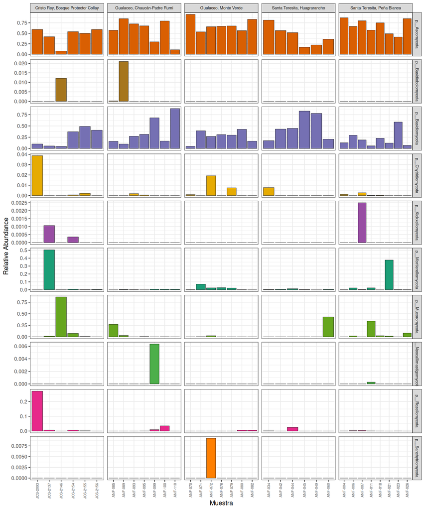

```r
# Vista en barras facetadas por Phylum y Localidad
phylum_df %>%
  dplyr::filter(Phylum %in% top10_phyla) %>%
  ggplot(aes(x = sample_names, y = Abundance, fill = Phylum)) +
  facet_grid(Phylum ~ localidad, scales = "free") +
  geom_bar(stat = "identity", color = "black", linewidth = 0.2) +
  scale_fill_manual(values = phylum_colors) +
  theme_bw() +
  labs(x = "Muestra", y = "Relative Abundance") +
  theme(legend.position = "none",
        axis.text.x = element_text(angle = 90, hjust = 1, vjust = 0.5, size = 6),
        strip.text = element_text(size = 7))
```

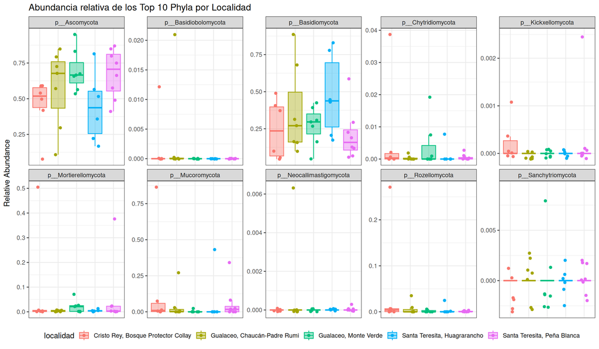

```r
### Boxplots + Jitter de los Top 10 Phyla comparando entre localidades
phylum_df %>%
  dplyr::filter(Phylum %in% top10_phyla) %>%
  ggplot(aes(x = localidad, y = Abundance, fill = localidad, color = localidad)) +
  facet_wrap(Phylum ~ ., scales = "free_y", nrow = 2) +
  geom_jitter(width = 0.2, size = 1.5) +
  geom_boxplot(outlier.shape = NA, alpha = 0.4) +
  scale_fill_manual(values = localidad_colors) +
  scale_color_manual(values = localidad_colors) +
  labs(title = "Abundancia relativa de los Top 10 Phyla por Localidad",
       x = NULL, y = "Relative Abundance") +
  theme_bw() +
  theme(legend.position = "bottom",
        axis.text.x = element_blank(),
        axis.ticks.x = element_blank())
```

INTERPRETATION #3: Make the above dotplot and boxplot for your sample types and your most abundant phyla. What initial conclusions can you draw regarding the sampled microbial communities as it relates to your scientific question?

### A1. `p__Ascomycota` (Localidad y Posición Vertical)

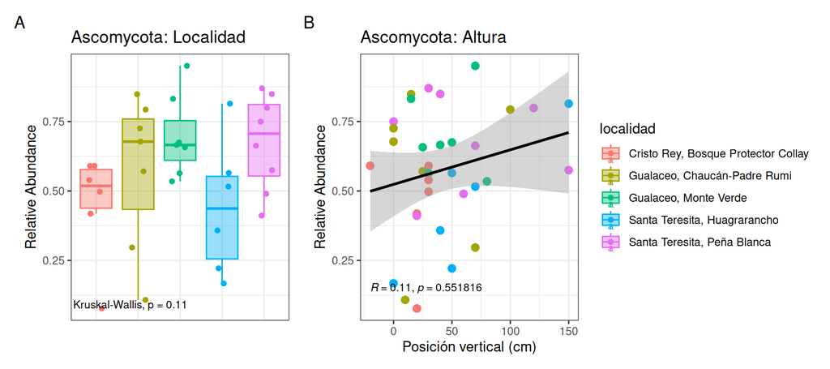

```r
# CATEGÓRICA: Localidad
ascomycota_phylum_loc <-
  phylum_df %>%
  dplyr::filter(Phylum == "p__Ascomycota") %>%
  ggplot(aes(x = localidad, y = Abundance,
             fill = localidad, color = localidad)) +
  geom_boxplot(alpha = 0.4, outlier.shape = NA) +
  geom_jitter(width = 0.2) +
  stat_compare_means(method = "kruskal.test", label.x.npc = "left", label.y.npc = "bottom", size = 3) +
  theme_bw() +
  labs(title = "Ascomycota: Localidad", x = NULL, y = "Relative Abundance") +
  scale_color_manual(values = localidad_colors) +
  scale_fill_manual(values = localidad_colors) +
  theme(axis.text.x = element_blank(),
        axis.ticks.x = element_blank(),
        legend.position = "right")

# CONTINUA: posicion_vertical_cm
ascomycota_phylum_altura <-
  phylum_df %>%
  dplyr::filter(Phylum == "p__Ascomycota") %>%
  ggplot(aes(x = posicion_vertical_cm, y = Abundance)) +
  geom_point(aes(color = localidad), size = 2.5) +
  theme_bw() +
  geom_smooth(method = "lm", color = "black", se = TRUE) +
  stat_cor(method = "spearman", label.x.npc = "left", label.y.npc = "bottom", size = 3) +
  labs(title = "Ascomycota: Altura", x = "Posición vertical (cm)", y = "Relative Abundance") +
  scale_color_manual(values = localidad_colors) +
  theme(legend.position = "none")

# Combinar ambos gráficos
ascomycota_phylum_loc + ascomycota_phylum_altura +
  plot_layout(guides = "collect") +
  plot_annotation(tag_levels = "A")
```

### A2. `p__Basidiomycota` (Localidad y Posición Vertical)

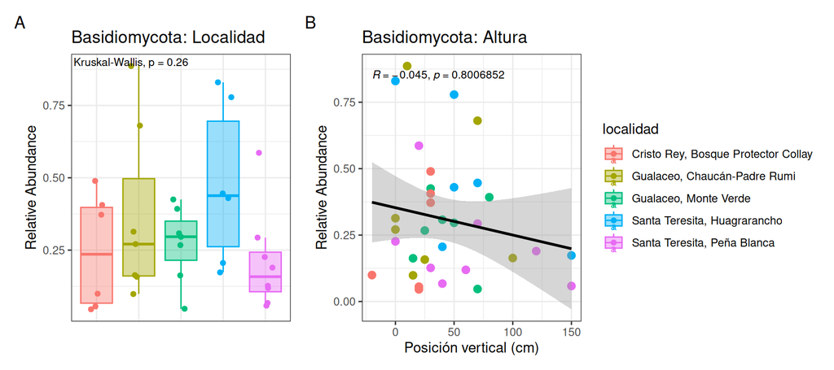

```r
# CATEGÓRICA: Localidad
basidiomycota_phylum_loc <-
  phylum_df %>%
  dplyr::filter(Phylum == "p__Basidiomycota") %>%
  ggplot(aes(x = localidad, y = Abundance,
             fill = localidad, color = localidad)) +
  geom_boxplot(alpha = 0.4, outlier.shape = NA) +
  geom_jitter(width = 0.2) +
  stat_compare_means(method = "kruskal.test", label.x.npc = "left", label.y.npc = "top", size = 3) +
  theme_bw() +
  labs(title = "Basidiomycota: Localidad", x = NULL, y = "Relative Abundance") +
  scale_color_manual(values = localidad_colors) +
  scale_fill_manual(values = localidad_colors) +
  theme(axis.text.x = element_blank(),
        axis.ticks.x = element_blank(),
        legend.position = "right")

# CONTINUA: posicion_vertical_cm
basidiomycota_phylum_altura <-
  phylum_df %>%
  dplyr::filter(Phylum == "p__Basidiomycota") %>%
  ggplot(aes(x = posicion_vertical_cm, y = Abundance)) +
  geom_point(aes(color = localidad), size = 2.5) +
  theme_bw() +
  geom_smooth(method = "lm", color = "black", se = TRUE) +
  stat_cor(method = "spearman", label.x.npc = "left", label.y.npc = "top", size = 3) +
  labs(title = "Basidiomycota: Altura", x = "Posición vertical (cm)", y = "Relative Abundance") +
  scale_color_manual(values = localidad_colors) +
  theme(legend.position = "none")

# Combinar ambos gráficos
basidiomycota_phylum_loc + basidiomycota_phylum_altura +
  plot_layout(guides = "collect") +
  plot_annotation(tag_levels = "A")
```

### A3. `p__Rozellomycota` y `p__Mortierellomycota` (Otros Phyla frecuentes)

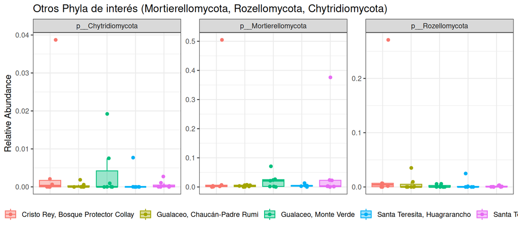

```r
# Explorar los siguientes 2 phyla más frecuentes
otros_phyla_loc <-
  phylum_df %>%
  dplyr::filter(Phylum %in% c("p__Mortierellomycota", "p__Rozellomycota", "p__Chytridiomycota")) %>%
  ggplot(aes(x = localidad, y = Abundance, fill = localidad, color = localidad)) +
  facet_wrap(. ~ Phylum, scales = "free_y", nrow = 1) +
  geom_boxplot(alpha = 0.4, outlier.shape = NA) +
  geom_jitter(width = 0.2) +
  scale_color_manual(values = localidad_colors) +
  scale_fill_manual(values = localidad_colors) +
  labs(title = "Otros Phyla de interés (Mortierellomycota, Rozellomycota, Chytridiomycota)",
       x = NULL, y = "Relative Abundance") +
  theme_bw() +
  theme(axis.text.x = element_blank(),
        axis.ticks.x = element_blank(),
        legend.position = "bottom")

otros_phyla_loc
```

INTERPRETATION #4: Based on these phylum-level analyses, were there any phyla that you were able to identify to focus on moving forward for deeper taxonomic analyses? Why?

## B. Genus

Calculamos el dataframe aglomerado a nivel de género (`Genus`).

```r
# Calculate the Genus relative abundance
genus_df <-
  scaled_physeq %>%
  # agglomerate at the genus level
  tax_glom(taxrank = "Genus") %>%
  # Transform counts to relative abundance
  transform_sample_counts(function (x) {x/sum(x)}) %>%
  # Melt to a long format
  psmelt()

# Revisar los 10 géneros más abundantes en todo el dataset
top10_genera <-
  genus_df %>%
  group_by(Phylum, Genus) %>%
  summarize(mean_PercAbund = round(mean(Abundance), digits = 4), .groups = "drop") %>%
  arrange(-mean_PercAbund)

top10_genera %>% datatable()
```

|  | Phylum | Genus | mean_PercAbund |
| --- | --- | --- | --- |
| 1 | p__Basidiomycota | g__Rhodotorula | 0.075 |
| 2 | p__Ascomycota | g__Cladosporium | 0.0566 |
| 3 | p__Mucoromycota | g__Mucor | 0.0526 |
| 4 | p__Basidiomycota | g__Vishniacozyma | 0.029 |
| 5 | p__Ascomycota | g__Plectosphaerella | 0.0281 |
| 6 | p__Basidiomycota | g__Malassezia | 0.025 |
| 7 | p__Ascomycota | g__Sarocladium | 0.0247 |
| 8 | p__Ascomycota | g__Aureobasidium | 0.023 |
| 9 | p__Ascomycota | g__Penicillium | 0.0229 |
| 10 | p__Ascomycota | g__Candida | 0.0216 |

[output cut: 723 more lines]

### B1. Géneros principales de `p__Ascomycota`

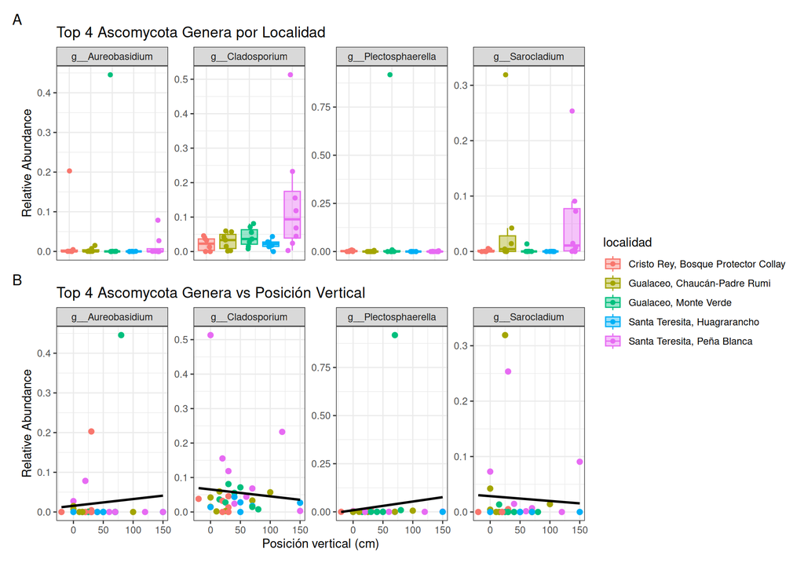

```r
# Identificar los 4 géneros más abundantes dentro de Ascomycota
top_asco_genera <-
  genus_df %>%
  dplyr::filter(Phylum == "p__Ascomycota") %>%
  group_by(Genus) %>%
  summarize(mean_Abund = mean(Abundance), .groups = "drop") %>%
  arrange(-mean_Abund) %>%
  head(n = 4) %>%
  pull(Genus)

# Categórica: Localidad
asco_genus_loc <-
  genus_df %>%
  dplyr::filter(Genus %in% top_asco_genera) %>%
  ggplot(aes(x = localidad, y = Abundance,
             fill = localidad, color = localidad)) +
  facet_wrap(. ~ Genus, scales = "free_y", nrow = 1) +
  geom_boxplot(alpha = 0.4, outlier.shape = NA) +
  geom_jitter(width = 0.2, size = 1.5) +
  theme_bw() +
  labs(title = "Top 4 Ascomycota Genera por Localidad", x = NULL, y = "Relative Abundance") +
  scale_color_manual(values = localidad_colors) +
  scale_fill_manual(values = localidad_colors) +
  theme(axis.text.x = element_blank(),
        axis.ticks.x = element_blank(),
        legend.position = "right")

# Continua: Posición vertical
asco_genus_altura <-
  genus_df %>%
  dplyr::filter(Genus %in% top_asco_genera) %>%
  ggplot(aes(x = posicion_vertical_cm, y = Abundance)) +
  facet_wrap(. ~ Genus, scales = "free_y", nrow = 1) +
  geom_point(aes(color = localidad), size = 2) +
  theme_bw() +
  geom_smooth(method = "lm", color = "black", se = FALSE) +
  labs(title = "Top 4 Ascomycota Genera vs Posición Vertical", x = "Posición vertical (cm)", y = "Relative Abundance") +
  scale_color_manual(values = localidad_colors) +
  theme(legend.position = "none")

# Combinar
asco_genus_loc / asco_genus_altura +
  plot_layout(guides = "collect") +
  plot_annotation(tag_levels = "A")
```

### B2. Géneros principales de `p__Basidiomycota`

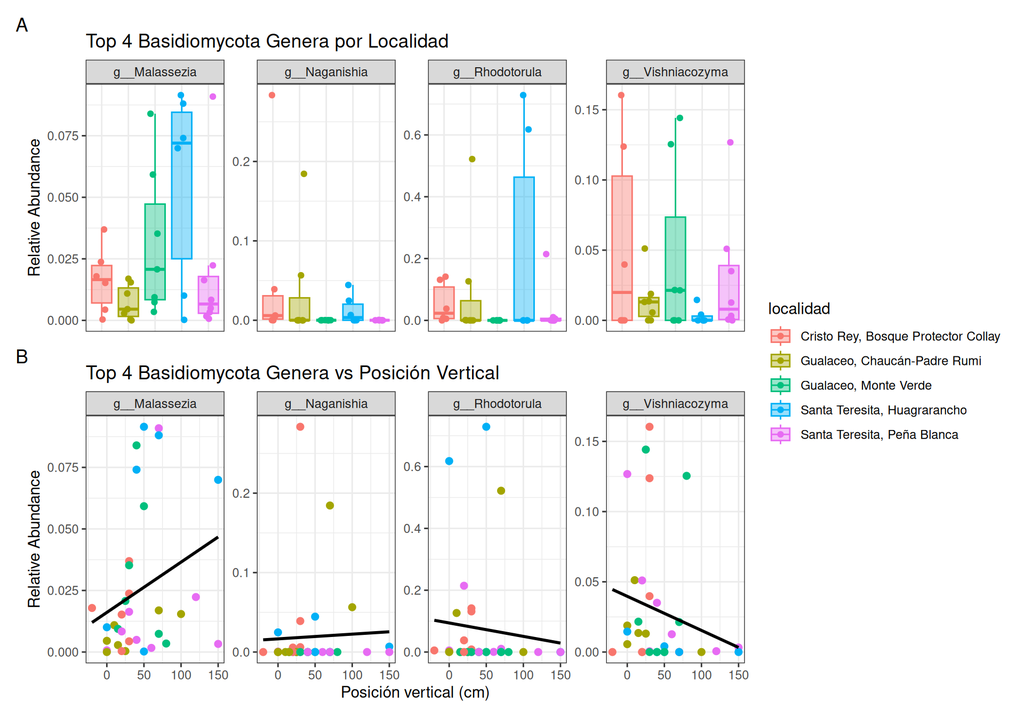

```r
# Identificar los 4 géneros más abundantes dentro de Basidiomycota
top_basidio_genera <-
  genus_df %>%
  dplyr::filter(Phylum == "p__Basidiomycota") %>%
  group_by(Genus) %>%
  summarize(mean_Abund = mean(Abundance), .groups = "drop") %>%
  arrange(-mean_Abund) %>%
  head(n = 4) %>%
  pull(Genus)

# Categórica: Localidad
basidio_genus_loc <-
  genus_df %>%
  dplyr::filter(Genus %in% top_basidio_genera) %>%
  ggplot(aes(x = localidad, y = Abundance,
             fill = localidad, color = localidad)) +
  facet_wrap(. ~ Genus, scales = "free_y", nrow = 1) +
  geom_boxplot(alpha = 0.4, outlier.shape = NA) +
  geom_jitter(width = 0.2, size = 1.5) +
  theme_bw() +
  labs(title = "Top 4 Basidiomycota Genera por Localidad", x = NULL, y = "Relative Abundance") +
  scale_color_manual(values = localidad_colors) +
  scale_fill_manual(values = localidad_colors) +
  theme(axis.text.x = element_blank(),
        axis.ticks.x = element_blank(),
        legend.position = "right")

# Continua: Posición vertical
basidio_genus_altura <-
  genus_df %>%
  dplyr::filter(Genus %in% top_basidio_genera) %>%
  ggplot(aes(x = posicion_vertical_cm, y = Abundance)) +
  facet_wrap(. ~ Genus, scales = "free_y", nrow = 1) +
  geom_point(aes(color = localidad), size = 2) +
  theme_bw() +
  geom_smooth(method = "lm", color = "black", se = FALSE) +
  labs(title = "Top 4 Basidiomycota Genera vs Posición Vertical", x = "Posición vertical (cm)", y = "Relative Abundance") +
  scale_color_manual(values = localidad_colors) +
  theme(legend.position = "none")

# Combinar
basidio_genus_loc / basidio_genus_altura +
  plot_layout(guides = "collect") +
  plot_annotation(tag_levels = "A")
```

INTERPRETATION #5: Please make some plots of mid-level taxonomic ranks (e.g. Genus, Family, Order) as it relates to your scientific question. Were there any changes in the mid-level taxonomic trends compared to the phylum-level results? What does that tell you about that taxonomic group?